# ICE ERO-LESA data Nov. 2023-Feb. 2025, Guantanamo detentions

UWCHR

2025-03-25

This notebook analyzes ICE enforcement data associated with detentions at Guantanamo Bay, Cuba. Datasets were obtained by the Deportation Data Project.

```r
options(scipen = 1000000)

library(pacman)

p_load(here, tidyverse, zoo, lubridate, ggplot2, plotly, gghighlight, viridis, readxl, digest, ggsankeyfier)

file <- "ice_detentions_nov23-feb25.csv.gz"

df <- read_delim(here('analyze', 'input', file), delim='|') %>%
  janitor::clean_names() %>%
  mutate(stay_book_in_date_time = ymd_hms(stay_book_in_date_time),
         book_in_date_time = ymd_hms(book_in_date_time),
         detention_book_out_date_time = ymd_hms(detention_book_out_date_time),
         stay_book_out_date_time = ymd_hms(stay_book_out_date_time),
         )

gitmo_codes <- c("GTMOACU", "GTMODCU")

# Get all placements at Guantanamo Bay detention facilities
gitmo_detentions <- df[df$detention_facility_code %in% c("GTMOACU", "GTMODCU"),]

# Confirm one record per individual unique identifier
stopifnot(nrow(gitmo_detentions) == length(unique(gitmo_detentions$unique_identifier)))

# Get all detention history records for individuals transferred to Guantanamo Bay
gitmo_detention_stays <- df[df$stayid %in% unique(gitmo_detentions$stayid),]

# Get all detention history records for individuals transferred to Guantanamo Bay
gitmo_detention_histories <- df[df$unique_identifier %in% unique(gitmo_detentions$unique_identifier),]
```

ICE detention data includes 765917 records of detention placements involving 368997 unique individuals, identified by the field `df$unique_identifier`.

ICE detention data represents records of detention transfers or book-outs from 2023-11-15 00:21:00 to 2025-02-18 00:19:00; therefore, some individual detention histories may be incomplete.

The dataset includes 179 records associated with transfers to two detention locations at Guantanamo Bay, Cuba: `detention_facility_code` values “GTMOACU” and “GTMODCU”, identified as JTF CAMP SIX and MIGRANT OPS CENTER MAIN AV622, respectively. These detention facilities do not appear in prior detention history datasets consulted by UWCHR.

In this case, each transfer to Guantanamo Bay is associated with a single individual as indicated by the `unique_identifier` field. By filtering the dataset for all records with matching `unique_identifier` values, we find a total of 718 detention history records associated with individuals transferred to Guantanamo Bay

At the time of production of the dataset, 178 placements at Guantanamo Bay facilities were ongoing, as indicated by empty `stay_release_reason` field; 1 placement at Guantanamo Bay was complete, with `stay_release_reason` indicating Transferred.

## Transfers to Guantanamo Bay

```r
transfer_dates <- gitmo_detentions %>%
  mutate(book_in_date = date(book_in_date_time)) %>%
  count(book_in_date)

transfer_sites <- gitmo_detentions %>%
  mutate(book_in_date = date(book_in_date_time)) %>%
  count(book_in_date, detention_facility)

transfer_sites_sum <- transfer_sites %>%
  group_by(detention_facility) %>%
  summarize(n = sum(n))

transfers_from <- gitmo_detentions %>%
  mutate(book_in_date = date(book_in_date_time)) %>%
  count(book_in_date, prev_facil)
```

The data record tranfers to Guantanamo Bay on 13 days from 2025-02-04 to 2025-02-17, with each transfers involving 7 to 15 people. It is not clear how these transfer dates compare with those documented via other reports.

Detained people transferred to Guantanamo Bay were associated with two different detention sites, with a total of 128 transfers to “JTF CAMP SIX” and 51 to “MIGRANT OPS CENTER MAIN AV622”. It is not immediately apparent what is indicated by this distinction.

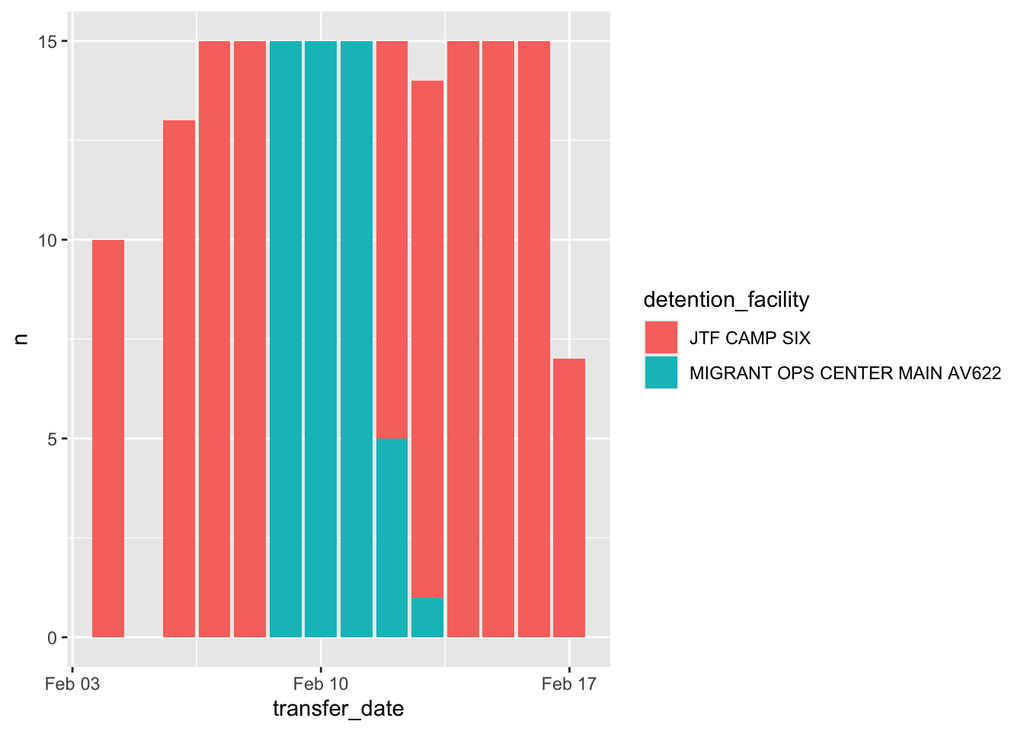

```r
p1 <- gitmo_detentions %>%
  mutate(transfer_date = date(book_in_date_time)) %>%
  count(transfer_date, detention_facility) %>%
  ggplot(aes(x = transfer_date, y = n, fill = detention_facility)) +
  geom_col()

p1
```

## Characteristics of detained people transferred to Guantanamo Bay

```r
gitmo_ind <- gitmo_detentions %>%
  distinct(unique_identifier, .keep_all = TRUE)

stopifnot(sum(gitmo_ind$gender == "Male") == nrow(gitmo_ind))
```

Recent detention history data includes a limited number of fields involving individual characteristics of detained people. (Note that in this case, each transfer to Guantanamo Bay involves a single person and there are no repeat transfers, so we could naively process the subset of transfer records to represent individual characteristics; for the sake of clarity, we generate a separate subset of records per distinct `unique_identifier` for this section.)

All individuals transferred were categorized as `gender` “Male”; where not missing, `ethnicity` is recorded as “Hispanic Origin”. The only other demographic field included is `marital_status`, with the following breakdown:

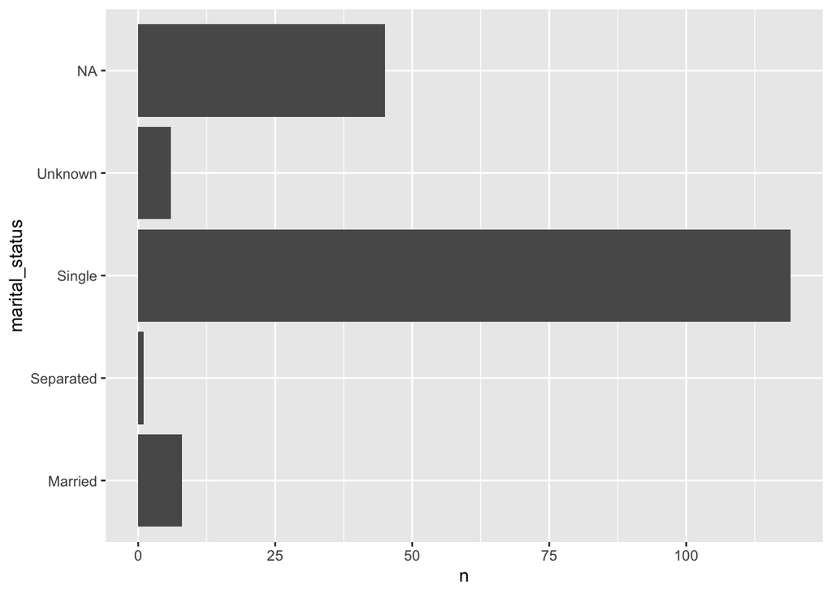

```r
p1 <- gitmo_ind %>%
  count(marital_status) %>%
  ggplot(aes(y = marital_status, x = n)) +
  geom_col()

p1
```

The dataset includes a limited number of fields that relate to the legal status of detained people:

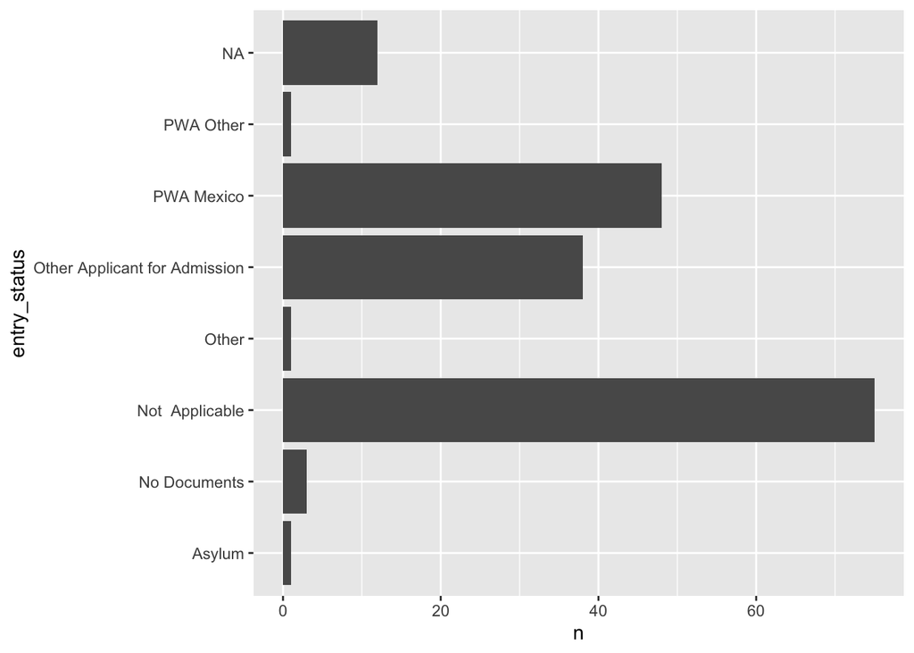

```r
p1 <- gitmo_ind %>%
  count(entry_status) %>%
  ggplot(aes(y = entry_status, x = n)) +
  geom_col()

p1
```

Most individuals transferred to Guantanamo did not have criminal convictions.

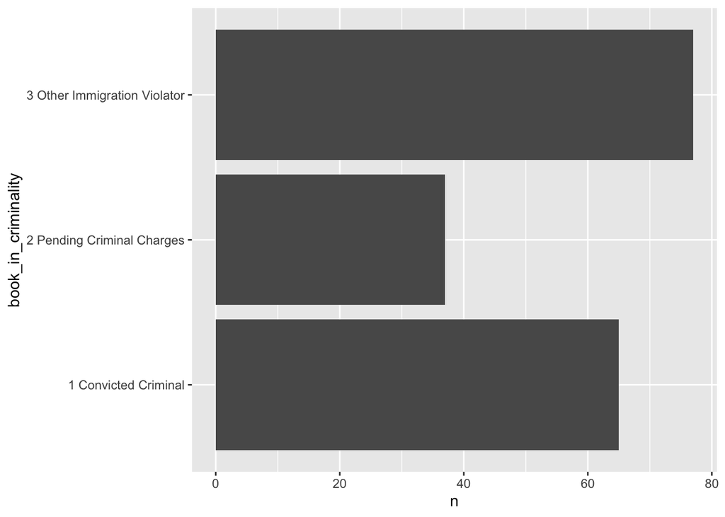

```r
p1 <- gitmo_ind %>%
  count(book_in_criminality) %>%
  ggplot(aes(y = book_in_criminality, x = n)) +
  geom_col()

p1
```

One individual was transferred to Guantanamo Bay despite lacking a final order of removal, with `case_category` encoded as “[8B] Excludable / Inadmissible - Under Adjudication by IJ”, indicating ongoing immigration hearings. This invidual was the only one represented in the dataset to be transferred away from Guantanamo Bay after a placement of approximately 3.71875 days.

```r
t1 <- gitmo_ind %>%
  count(case_category)

knitr::kable(t1)
```

| case_category | n |
| --- | --- |
| [11] Administrative Deportation / Removal | 2 |
| [16] Reinstated Final Order | 17 |
| [3] Deportable - Administratively Final Order | 2 |
| [8B] Excludable / Inadmissible - Under Adjudication by IJ | 1 |
| [8C] Excludable / Inadmissible - Administrative Final Order Issued | 105 |
| [8F] Expedited Removal | 9 |
| [8G] Expedited Removal - Credible Fear Referral | 43 |

```r
initial_placements <- gitmo_detention_stays %>%
  filter(placement_count == 1)

stopifnot(nrow(initial_placements) == sum(initial_placements$initial_placement_approx))
```

For detention stays associated with transfers to Guantanamo, the earliest `stay_book_in_date_time` value is 2023-11-17 11:00:00, and the latest is 2025-02-12 13:56:00.

As noted above, all detention stays associated with transfers to Guantanamo Bay were ongoing at the time of production of the dataset on February 18, 2025. This suggests that the current dataset contains full detention history records for all stays associated with transfers to Guantanamo bay.

We can calculate the elapsed detention stay time per individual, with a range of 5.4194444 to 458.5416667 days and an average of 125.2916822 days.

During stays associated with transfers to Guantanamo, detained people had experienced on average 4.1987281 facility placements, with a range of 2 to 11 placements, including at Guantanamo.

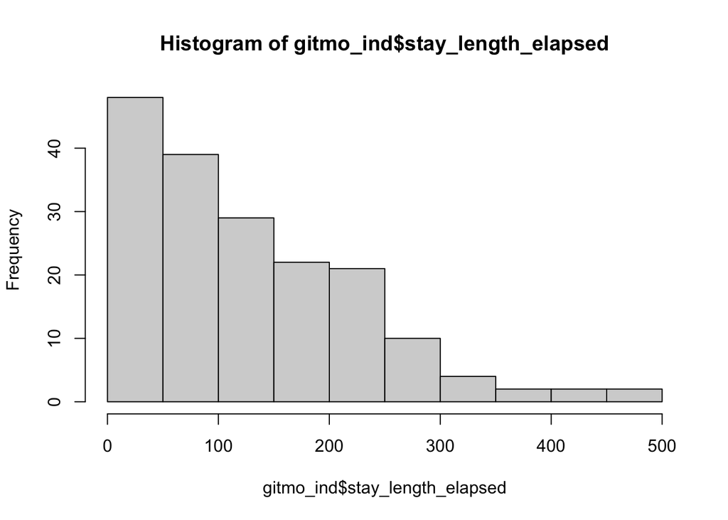

```r
hist(gitmo_ind$stay_length_elapsed)
```

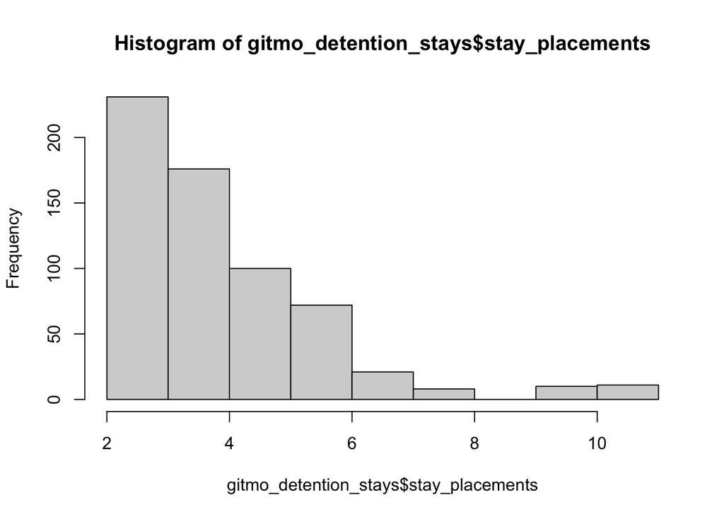

```r
hist(gitmo_detention_stays$stay_placements)
```

Of individuals transferred to Guantanamo Bay, 143 were experiencing their first stay in detention. 36 had experienced more than one detention stay; with 33 experiencing 2 stays and 3 experiencing 3 stays.

```r
# Stays associated with transfers to Guantanamo
gitmo_stays <- unique(gitmo_detention_stays$stayid)

# Prior completed stays for individuals associated with transfers to Guantanamo
prior_stays <- gitmo_detention_histories %>%
  filter(!stayid %in% gitmo_stays)

prior_release <- prior_stays %>%
  mutate(release_reason = case_when(str_detect(stay_release_reason, "Order|Parole") ~ "OR/OS/Parole",
                                    TRUE ~ stay_release_reason)) %>%
  count(release_reason)
```

Of these 89 prior stays, a total of 62 ended with release on an Order of Recognizance, Order of Supervision, or Parole, including humanitarian release. Remaining stays ended with removals or transfers to USMS or unspecified agencies.

```r
t1 <- prior_stays %>%
  mutate(stay_release_reason = str_trunc(stay_release_reason, 40)) %>%
  count(stay_release_reason)

knitr::kable(t1)
```

| stay_release_reason | n |
| --- | --- |
| Order of Recognizance - Humanitarian | 1 |
| Order of Supervision - Humanitarian | 2 |
| Order of Supervision - No SLRRFF | 26 |
| Order of recognizance | 1 |
| Order of supervision | 22 |
| Paroled | 10 |
| Removed | 13 |
| Transferred | 2 |
| U.S. Marshals or other agency (explai… | 12 |

## ICE Arrests data

```r
file <- "ERO_Admin_Arrests_2025-ICLI-00019_2024-ICFO-39357_LESA-STU_FINAL_raw.xlsx"

arr <- read_excel(here('analyze', 'input', file), skip=6) %>%
  janitor::clean_names() %>%
  mutate(apprehension_date = as.Date(apprehension_date)) |>
  mutate(apprehension_method = fct(apprehension_method)) |>
  mutate(criminality = apprehension_criminality == "1 Convicted Criminal") |>
  mutate(n_dupe = row_number(), .by = c("apprehension_date", "apprehension_method", "apprehension_criminality", "unique_identifier")) |>
  filter(is.na(unique_identifier) | n_dupe == 1) |>
  mutate(week = floor_date(apprehension_date, "week", week_start = "Monday"))

arr_ids <- arr$unique_identifier

gitmo_arr <- arr %>%
  filter(unique_identifier %in% unlist(gitmo_ind$unique_identifier))
```

ICE arrests data for the same time period include 92 records matching `unique_identifier` values associated with transfers to Guantanamo, with 83 unique identifier values.

Individuals represented in the detention history dataset but not in the ICE arrests dataset may have been arrested by ICE prior to the period covered by the arrests dataset; or may have been transferred to ICE detention custody from CBP; current detention data lacks a `final_program` field which would indicate this.

The ICE arrests data reveal that all of the individuals transferred to Guantanamo are Venezuelan males. All but 1 were subject to a final order of removal, as discussed above.

The following charts explore various characteristics of the arrests data for these individuals:

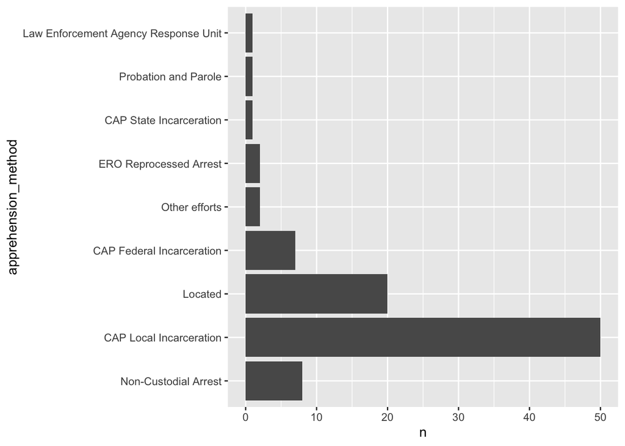

```r
stopifnot(prop.table(table(as.factor(gitmo_arr$citizenship_country))['VENEZUELA']) == 1)

stopifnot(prop.table(table(as.factor(gitmo_arr$gender))['Male']) == 1)

p1 <- gitmo_arr %>%
  count(apprehension_method) %>%
  ggplot(aes(y = apprehension_method, x = n)) +
  geom_col()

p1
```

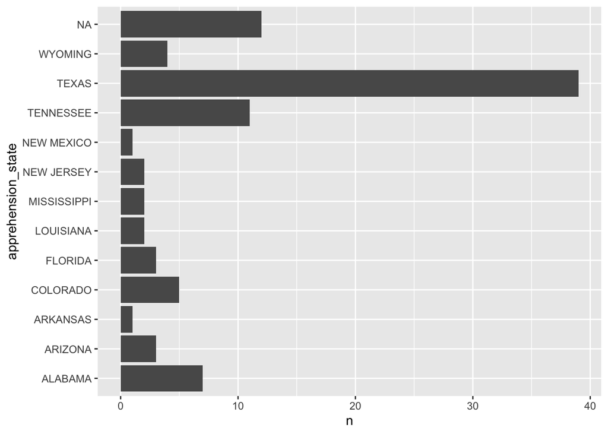

```r
p2 <- gitmo_arr %>%
  count(apprehension_state) %>%
  ggplot(aes(y = apprehension_state, x = n)) +
  geom_col()

p2
```

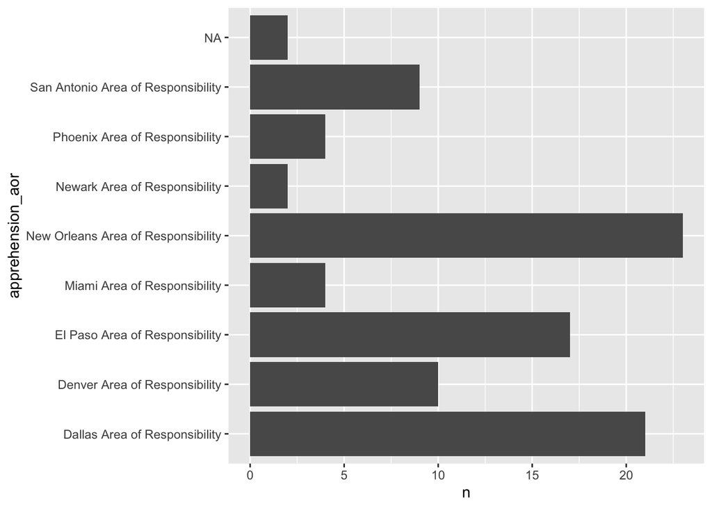

```r
p3 <- gitmo_arr %>%
  count(apprehension_aor) %>%
  ggplot(aes(y = apprehension_aor, x = n)) +
  geom_col()

p3
```

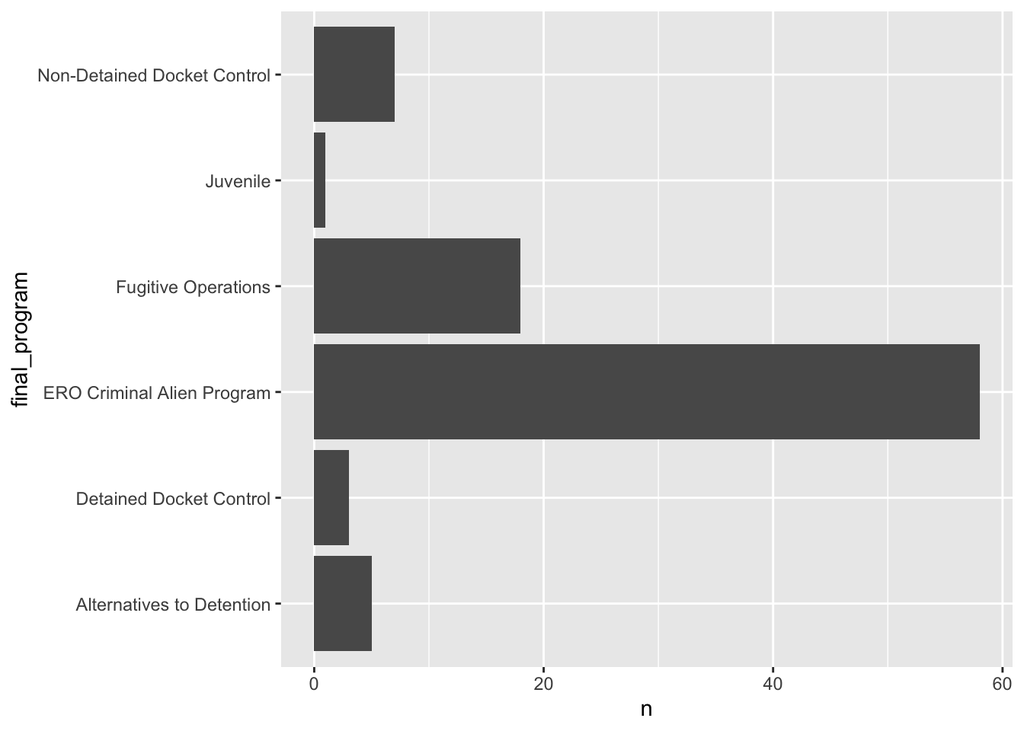

```r
p4 <- gitmo_arr %>%
  count(final_program) %>%
  ggplot(aes(y = final_program, x = n)) +
  geom_col()

p4
```

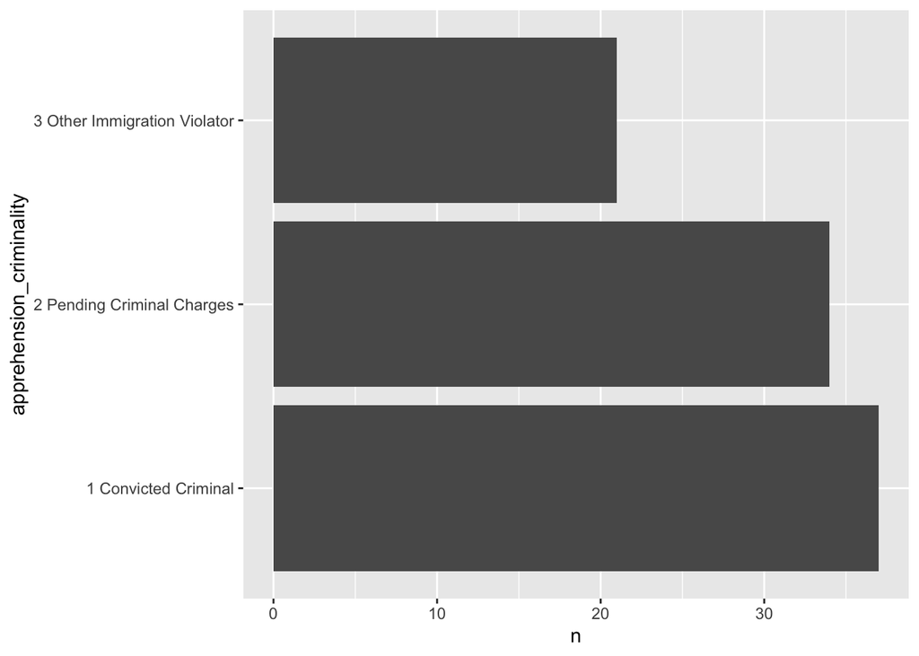

```r
p5 <- gitmo_arr %>%
  count(apprehension_criminality) %>%
  ggplot(aes(y = apprehension_criminality, x = n)) +
  geom_col()

p5
```

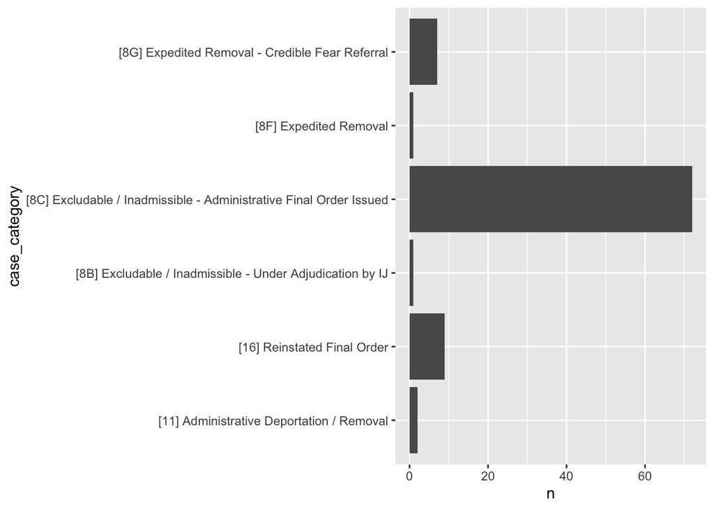

```r
p6 <- gitmo_arr %>%
  count(case_category) %>%
  ggplot(aes(y = case_category, x = n)) +
  geom_col()

p6
```

## Detention flow

The following experimental plot explores a method of visualizing detention flows for all stays involving transfers to Guantanamo sites. Note y-axis not to scale in current version.

To-do:

- Ordinal detention stages relative to Guantanamo placements
- Categorical detention stages: initial, current or Guantanamo facilities
- Better scaling of Y axis, or label quantities
- Better plot margins
- Detention flow by other case/facility characteristics

```r
dat <- gitmo_detention_stays %>%
  dplyr::select(stayid, detention_facility_code, placement_count, stay_placements, current_placement) %>%
  mutate(relative_placement = placement_count - stay_placements)

dat_wide <- dat %>%
  pivot_wider(id_cols = c(stayid), names_from = relative_placement, names_prefix = "facil_n", values_from = detention_facility_code)

flows_gtmo <- dat_wide %>%
  dplyr::select(-c(stayid)) %>%
  group_by_all() %>%
  summarize(n = n()) %>%
  arrange(desc(n))
```

[output not shown]

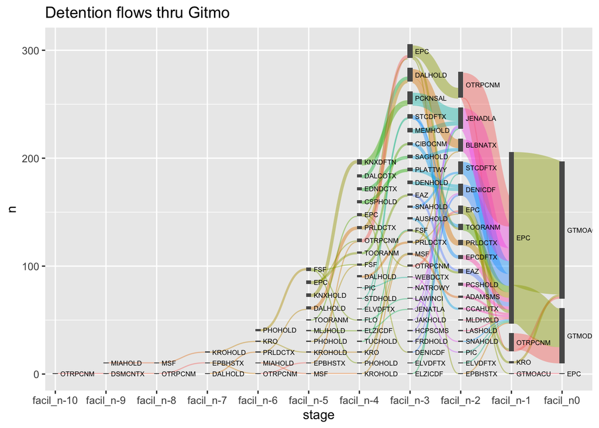

```r
stages = c("facil_n-10",
           "facil_n-9",
           "facil_n-8",
           "facil_n-7",
           "facil_n-6",
           "facil_n-5",
           "facil_n-4",
           "facil_n-3",
           "facil_n-2",
           "facil_n-1",
           "facil_n0")

flows_gtmo_long <- flows_gtmo %>%
  pivot_stages_longer(stages_from = stages,
                      values_from = "n") %>%
  filter(!is.na(node))

p1 <- ggplot(flows_gtmo_long,
       aes(x = stage, y = n, group = node,
           connector = connector, edge_id = edge_id)) +
  geom_sankeyedge(v_space = "auto", alpha=.5, aes(fill = node)) +
  geom_sankeynode(v_space = "auto") +
  labs(title = "Detention flows thru Gitmo")

pos <- position_sankey(v_space = "auto")
pos_text <- position_sankey(v_space = "auto", nudge_x = 0.1)

p1 + geom_sankeyedge(aes(fill = node), position = pos) +
  geom_sankeynode(position = pos) +
  geom_text(aes(label = node), stat = "sankeynode", position = pos_text, hjust = 0, cex = 2) +
  scale_x_discrete(expand = expansion(add = c(0.2, .6))) +
  # scale_y_discrete(labels = NULL, breaks = NULL) +
  # labs(y = NULL) +
  guides(fill = FALSE)
```